# PyData2019Highlights slides

## Introduction

Three main sections

1. Coding ideas
2. Visualisation
3. Fun stuff

## Coding ideas

1. Testing
2. Features in 3.8
3. Vaex
4. Time series forecasting

### Testing

- [Talk](https://youtu.be/WTj6T0QdHHM)
- `pandas.testing.assert...`
- `pytest.mark.parametrize()`
- [Pytruth](https://github.com/google/pytruth)
- Coverage:
  - `pip install pytest-cov`
  - `pytest --cov=myproj tests/` will produce the following:

```
-------------------- coverage: ... ---------------------
Name                 Stmts   Miss  Cover
----------------------------------------
myproj/__init__          2      0   100%
myproj/myproj          257     13    94%
myproj/feature4286      94      7    92%
----------------------------------------
TOTAL                  353     20    94%
```

- Given/When/Then

### Testing

- [Hypothesis](https://github.com/HypothesisWorks/hypothesis) - Property based testing

[figure not shown]

```python
### Hypothesis strategies allow you to create different examples to test your code one.
from hypothesis.strategies import text, lists
for i in range(0,10):
    print(lists(text()).example())
```

```
['$', '\U000933d2\x06\U000da7bf\uf3a0(\x13\r\U000b1a38\x16"\U0007de83', '\x0e\U000b197c', "+\U00108f53'\x03"]
["\U00087abd\U0004cc41'\x03"]
['\x1c', '\x04', '\U000976ab']
[]
[]
['\x15\x17', '𬪐\U000ddbc2', '\U00077f69\U0007e7d3\U000d34c1퀪\x02\x1b', '/\U000d23fc/\x05%\U000119cb籛𪂥']
['#\U000a74e0', '\U0010f10f,', '\U000fe9360', '\U0005c636"ⴧ\x1f\x05𥵒\U000a5937\x0e', '\U00058c87𠭥\x10\x08', '\U0005a0b1']
[]
['', '\x02-\U00106371\x02\U000fa6a3']
[]
```

### Features in 3.8

- Expected release: 2019-10-21
- [Summary](https://docs.python.org/3.8/whatsnew/3.8.html)
  - Side note: PEP="Python Enhancement Proposal". [PEP1](https://legacy.python.org/dev/peps/pep-0001/) explains its purpose and guidelines
- There is new syntax (the “walrus operator”, `:=`) to assign values to variables as part of an expression. Example:

  ```
  if (n := len(a)) > 10:
    print(f"List is too long ({n} elements, expected <= 10)")
  ```

- There is new syntax (`/`) to indicate that some function parameters must be specified positionally (i.e., cannot be used as keyword arguments):

  ```
  def pow(x, y, z=None, /):
    r = x**y
    if z is not None:
        r %= z
    return r
  ```

  Now `pow(2, 10)` and `pow(2, 10, 17)` are valid calls, but `pow(x=2, y=10)` and `pow(2, 10, z=17)` are invalid.

### Features in 3.8

- f-strings:

  ```
  x = 3
  print(f'{x*9 + 15=}')
  ```

  Would print `x*9 + 15=42`
- A continue statement was illegal in the `finally` clause due to a problem with the implementation. In Python 3.8 this restriction was lifted. (Contributed by Serhiy Storchaka in bpo-32489.)
  - `finally` is used in `try`/`except` clause
- Dict and dictviews are now iterable in reversed insertion order using reversed(). (Contributed by Rémi Lapeyre in bpo-33462.)

### Other Topics

#### Vaex

- [Talk](https://youtu.be/WTj6T0QdHHM?list=PLGVZCDnMOq0ocea1dd0it7jX7HgvZCjSW)
- A package similar to pandas which uses dataframes to manipulate and load large amounts of data
- Uses techniques such as saving filters and just in time calculation

#### Forecasting time series

- [Prophet and spotify](https://youtu.be/WTj6T0QdHHM?list=PLGVZCDnMOq0ocea1dd0it7jX7HgvZCjSW) - Prophet is time series forecasting package developed by Facebook 3 years ago.
- [Time Series Forecasting and Energy](https://www.youtube.com/watch?v=p6mKFs6HVlg&list=PLGVZCDnMOq0ocea1dd0it7jX7HgvZCjSW&index=48)

#### PyMC3

- [Markov chain monte carlo using PyMC3](https://www.youtube.com/watch?v=SS_pqgFziAg&list=PLGVZCDnMOq0ocea1dd0it7jX7HgvZCjSW&index=12&t=6s)

#### Success Rates

- [Exchange Network Dynamics](https://www.youtube.com/watch?v=kvQ5WdJ49CQ&list=PLGVZCDnMOq0ocea1dd0it7jX7HgvZCjSW&index=27&t=0s)

## Visualisation

1. Notebooks and presentations
2. Notebooks and widgets
3. Pandas plot backend

### How to make a presentation from your notebook

On each cell you have an option to view as a slide. This allows you to choose if you want to hide the cell or have it as a slide.

- In Jupyter Notebook, you go to "View">"Cell Toolbar">"Slideshow"

[figure not shown]

- In Jupyter Lab, you go to "Notebook Tools"

[figure not shown]

Once you have setup which cells are in the presentation, you can run the following in a terminal:

```
jupyter nbconvert <name_of_notebook>.ipynb --to slides
```

Tip: You can include a picture using the following code in your markdown:

```
<img src="<relative_path>/<image_name>.png">
```

Another tip: Use ` or ``` for code highlighting as above

### Widgets

You need to run:

```
jupyter nbextension enable --py --sys-prefix widgetsnbextension
```

```python
import ipywidgets as widgets
from ipywidgets import HBox, VBox
from ipywidgets.embed import embed_minimal_html
import numpy as np
import matplotlib.pyplot as plt
from IPython.display import display
%matplotlib inline

@widgets.interact(
    color=['blue', 'red', 'green'], lw=(1., 10.))
def plot(freq=1., color='blue', lw=2, grid=True):
    t = np.linspace(-1., +1., 1000)
    fig, ax = plt.subplots(1, 1, figsize=(8, 6))
    ax.plot(t, np.sin(2 * np.pi * freq * t),
            lw=lw, color=color)
    ax.grid(grid)
```

The following needs a kernel, therefore only showing a gif:

[figure not shown]

### Advanced widgets and solutions for sharing notebooks

[Video](https://youtu.be/NQYjXKmr8Tc?list=PLGVZCDnMOq0ocea1dd0it7jX7HgvZCjSW&t=1804)

### What is new in pandas 0.25.0?

Full release notes: https://pandas.pydata.org/pandas-docs/stable/whatsnew/v0.25.0.html#enhancements

- Groupby enhancements for `.agg()`
  - Named aggregation is the recommended replacement for the deprecated “dict-of-dicts” approach to naming the output of column-specific aggregations (Deprecate groupby.agg() with a dictionary when renaming).
- [Dynamic plotting backend](https://youtu.be/NQYjXKmr8Tc?list=PLGVZCDnMOq0ocea1dd0it7jX7HgvZCjSW&t=1044)
- [`pd.read_fwf()`](https://youtu.be/QkQ5HHEu1b4?list=PLGVZCDnMOq0ocea1dd0it7jX7HgvZCjSW&t=1568)

#### Groupby

```
In [1]: animals = pd.DataFrame({'kind': ['cat', 'dog', 'cat', 'dog'],
   ...:                         'height': [9.1, 6.0, 9.5, 34.0],
   ...:                         'weight': [7.9, 7.5, 9.9, 198.0]})
   ...:

In [2]: animals
Out[2]:
  kind  height  weight
0  cat     9.1     7.9
1  dog     6.0     7.5
2  cat     9.5     9.9
3  dog    34.0   198.0

[4 rows x 3 columns]

In [3]: animals.groupby("kind").agg(
   ...:     min_height=pd.NamedAgg(column='height', aggfunc='min'),
   ...:     max_height=pd.NamedAgg(column='height', aggfunc='max'),
   ...:     average_weight=pd.NamedAgg(column='weight', aggfunc=np.mean),
   ...: )
   ...:
Out[3]:
      min_height  max_height  average_weight
kind
cat          9.1         9.5            8.90
dog          6.0        34.0          102.75

[2 rows x 3 columns]
```

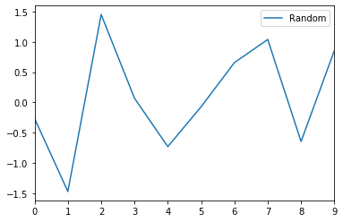

```python
%matplotlib inline
import pandas as pd
df = pd.DataFrame(pd.np.random.randn(10,1), columns=['Random'])
df.plot()
```

```python
pd.options.plotting.backend = 'hvplot'
df.plot()
```

[interactive chart not shown]

## Fun Stuff

1. Cycling
2. Bosch bot
3. Turing Way
4. Other topics

### Safer Cycling

- Combining raspberry pi and led light strip with machine learning to identify different vehicles behind you when cycling

[figure not shown]

### Safer Cycling

- Once the model is trained the weights on the neural network can be stored with a lower degree of accuracy. The model can then be compiled specifically for the TPU which optimises the memory using the fact that we only want to store our weights to 4 significant figures
- This improves speed of classification from ~300 ms to ~20 ms
- [Talk](https://www.youtube.com/watch?v=UmDeKDgFRj4&feature=youtu.be&t=1)
- Model: [Mobilenet SSD v1](https://github.com/tensorflow/models/blob/master/research/object_detection/g3doc/detection_model_zoo.md) trained on [COCO dataset](http://cocodataset.org)

### Bosch Bot

- [Wikipedia](https://en.wikipedia.org/wiki/The_Garden_of_Earthly_Delights) - "The Garden of Earthly Delights is the modern title given to a triptych oil painting on oak panel painted by the Early Netherlandish master Hieronymus Bosch"

[figure not shown]

### Bosch Bot

- [Twitter](https://twitter.com/boschbot?lang=en) - "Bits of Hieronymus Bosch's Garden Of Earthly Delights every few hours."

[figure not shown]

### Bosch Bot

- [Talk](https://youtu.be/UzGZtgu3PBM)
- Lynn Cherny created dashboard to visualise which snippets were liked the most. She also demonstrated an NLP model to replace words in poetry.

[figure not shown]

### Turing Way

- A project started by the Turing Institute to encourage reproducible research
- "The goal is to ensure that all results can be independently verified and built upon in future work"
- [Talk](https://www.youtube.com/watch?v=IG3PcZ6EhiU)
- [The Turing Way Book](https://the-turing-way.netlify.com)
- [Academic errors have real world effects](https://statmodeling.stat.columbia.edu/2013/04/16/memo-to-reinhart-and-rogoff-i-think-its-best-to-admit-your-errors-and-go-on-from-there/)

#### Quantamental Investing

- [Talk](https://www.youtube.com/watch?v=IG3PcZ6EhiU)
- Combining discretionary trading with systematic strategies. Creating quantitative solutions to deal with bias in human decision making process using ideas from Daniel Kahneman

#### Causal Inference

- The book of Why By Judea Perl

### And Finally....

[Alphabetical order](https://vimeo.com/150423718#t=4m45s)